# CITS4009-project2

# Part5 Clustering

Considering the diversity of readers, we will answer a few common questions at the beginning of Clustering:

Do you need a target variable for clustering?

No, clustering does not require a target variable. Clustering is an unsupervised learning method, which means it seeks to identify patterns or groups in the data without the use of previously labeled examples. It relies on the inherent structure and distribution of the data.

Which clustering technique will we use?

The choice of clustering technique often depends on the dataset and the specific problem at hand. Common methods include:

K-Means Clustering: Best suited for spherical clusters when the number of clusters (K) is known or can be estimated.

Hierarchical Clustering: Appropriate when a tree-like structure is preferred or when one wishes to understand the hierarchical relationships within the data.

DBSCAN (Density-Based Spatial Clustering of Applications with Noise): Suitable for clusters of varying shapes and for data with noise.

For this particular task, we will employ both Hierarchical Clustering and K-Means Clustering. The reason for this is because Hierarchical Clustering offers a comprehensive visualization that aids in understanding the potential cluster groupings at various levels of granularity. On the other hand, K-Means Clustering is computationally efficient and works well when the number of clusters can be reasonably estimated.

How to set parameters? How do you determine an appropriate K value for clustering?

Parameter setting often combines domain knowledge, empirical testing, and experimentation. For K-Means, a typical technique to ascertain the K value is the Elbow Method. By plotting the sum of squared distances for various K values, the “elbow” of the curve represents an optimal value for K, striking a balance between precision and computational cost.

How do you evaluate clustering performance?

Evaluating clustering performance can be a challenge, especially given its unsupervised nature. Internal metrics such as the Silhouette Coefficient, Davies-Bouldin Index, and Calinski-Harabasz Index are used to gauge the quality of clusters without any external benchmark. If ground truth labels are available, even if not used in the clustering process, external metrics like the Adjusted Rand Index or Normalized Mutual Information can be employed.

What insights can be drawn from the clustering results?

Clustering can yield diverse insights depending on the context. In the realm of market segmentation, it can spotlight varied customer behavior patterns. In biology, it may identify previously unknown species or genes with analogous functions. It is crucial to interpret the clusters in the context of the domain and the specific problem being addressed.

What distinguishes clustering from classification?

While both clustering and classification are methods used for grouping data points, they serve divergent purposes. Clustering, an unsupervised learning approach, groups data points based on inherent similarities without predefined labels. In contrast, classification, a supervised learning method, predicts the predefined label of a data point leveraging its features. Classification has a clear target variable, whereas clustering seeks to discern structure within the data.

## 5.1 Data preprocessing

### Data Import

In this section, we are working with a pre-processed and cleaned dataset to prepare it for clustering.

```r
clustering_data <- clustering_data[,c("country","category","subscribers","video_views",
"uploads","video_views_last_30_days","monthly_earnings_low","monthly_earning_high","yearly_earning_low","yearly_earning_high","subs_last_30_days","tertiary_edu_enrollment","population","unemployment_rate" ,"urban_population")]
```

The frequency of occurrence of each country and category in the dataset was first calculated. Based on these frequencies, countries and categories with fewer occurrences were identified, and then these less frequent countries and “unknown” categories were replaced with the generic country “world” label and category “other” label to effectively aggregate the data. We do this first to reduce noise, and in large datasets, certain categories may be underrepresented.

During the clustering process, these sparse data points may be seen as noise or outliers. Aggregating them under common labels ensures that they do not adversely affect the overall clustering results, and secondly, this can enhance interpretability, the presence of secondary categories can complicate the interpretation of clustering results. Through aggregation, the data structure can be simplified to make the clustering results clearer and easier to interpret, as we need to consider different readers’ reading needs, and most of the audiences are not able to read complex clustering results quickly. Furthermore this can improve efficiency, dealing with too many separate categories may increase the computational complexity of the clustering algorithm. Reducing the number of categories can speed up the algorithm.

After we perform the operation, we again convert the data type to the Factor type to prevent the previous substitution will be non-existent Factor.

```r
# Calculate the frequency of each country
country_counts <- table(clustering_data$country)
categories_counts <- table(clustering_data$category)

# Replace countries with fewer than 5 occurrences with "World", and categories with fewer than 5 occurrences with "Others"
countries_to_replace <- names(country_counts[country_counts < 5])
categories_to_replace <- names(categories_counts[categories_counts < 5])

# Convert factor columns to character type
clustering_data$country <- as.character(clustering_data$country)
clustering_data$category <- as.character(clustering_data$category)

# Replace the names of the countries in the list with "World"
clustering_data$country[clustering_data$country %in% countries_to_replace] <- "World"
clustering_data$country[clustering_data$country == "Unknown"] <- "World"

# Replace the names of the categories in the list with "Others"
clustering_data$category[clustering_data$category %in% categories_to_replace] <- "Others"

# Convert back to factor type
clustering_data$country <- as.factor(clustering_data$country)
clustering_data$category <- as.factor(clustering_data$category)
```

## 5.3 Finding Best K

Due to the breadth of the audience present in the report, we will explain the role of each function all over again for better comprehensibility.

First, define helper functions to compute distances and evaluate cluster quality.

Then, define a function to calculate the Calinski-Harabasz Index using either k-means or hierarchical clustering. This function will be instrumental in determining the best number of clusters for the dataset.

Finally, compute the CH Index for the dataset, providing insights into the optimal number of clusters.

The sqr_euDist function computes the squared Euclidean distance between two points. This is a common distance measure used in clustering algorithms.The Calinski-Harabasz Index helps make this determination by measuring the ratio of the sum of between-cluster dispersion to within-cluster dispersion.

The functions wss, wss_total, and tss compute the Within-Cluster Sum of Squares, total WSS, and Total Sum of Squares, respectively. These metrics help evaluate the compactness of the clusters.Functions like WSS and TSS provide metrics that can help assess the quality of the clusters. They ensure the clusters are tight and well-separated.

The CH_index function computes the Calinski-Harabasz Index, a metric used to determine the optimal number of clusters. This function is designed to work with either hierarchical clustering or k-means clustering.By allowing the choice between kmeans and hclust in the CH_index function, the code provides flexibility in the clustering approach. Different datasets or use cases might favor one method over the other

```r
# Define a function to compute the squared Euclidean distance between two points x and y
sqr_euDist <- function(x, y) {
  sum((x - y)^2)
}

# Define a function to compute the Within-Cluster Sum of Squares (WSS) for a given cluster matrix
wss <- function(clustermat) {
  c0 <- colMeans(clustermat)
  sum(apply(clustermat, 1, FUN=function(row) {sqr_euDist(row, c0)}))
}

# Define a function to compute the total WSS for all clusters
wss_total <- function(scaled_df, labels) {
  wss_sum <- 0
  k <- length(unique(labels))
  for (i in 1:k)
    wss_sum <- wss_sum + wss(subset(scaled_df, labels == i))
  wss_sum
}

# Define a function to compute the Total Sum of Squares (TSS)
tss <- function(scaled_df) {
  wss(scaled_df)
}

# Define a function to compute the Calinski-Harabasz Index (CH Index) using either hierarchical clustering or k-means clustering
# The CH Index is useful for determining the optimal number of clusters
CH_index <- function(scaled_df, kmax, method="kmeans") {
  if (!(method %in% c("kmeans", "hclust")))
    stop("method must be one of c('kmeans', 'hclust')")
  npts <- nrow(scaled_df)
  wss_value <- numeric(kmax)
  wss_value[1] <- wss(scaled_df)

  if (method == "kmeans") {
    for (k in 2:kmax) {
      clustering <- kmeans(scaled_df, k, nstart=10, iter.max=100)
      wss_value[k] <- clustering$tot.withinss
    }
  } else {
    d <- dist(scaled_df, method="euclidean")
    pfit <- hclust(d, method="ward.D2")
    for (k in 2:kmax) {
      labels <- cutree(pfit, k=k)
      wss_value[k] <- wss_total(scaled_df, labels)
    }
  }

  bss_value <- tss(scaled_df) - wss_value
  B <- bss_value / (0:(kmax-1))
  W <- wss_value / (npts - 1:kmax)
  data.frame(k = 1:kmax, CH_index = B/W, WSS = wss_value)
}
```

## 5.4 hierarchical clustering

The code first sets up the configurations for hierarchical clustering.

It then loops through each combination, performing clustering and visualizing the results. This iterative approach ensures that we evaluate multiple configurations to find the best one.

After examining the various dendrograms, we can finalize the clustering by extracting the cluster memberships. This final step provides actionable labels for each data point, allowing for further insights and analysis.

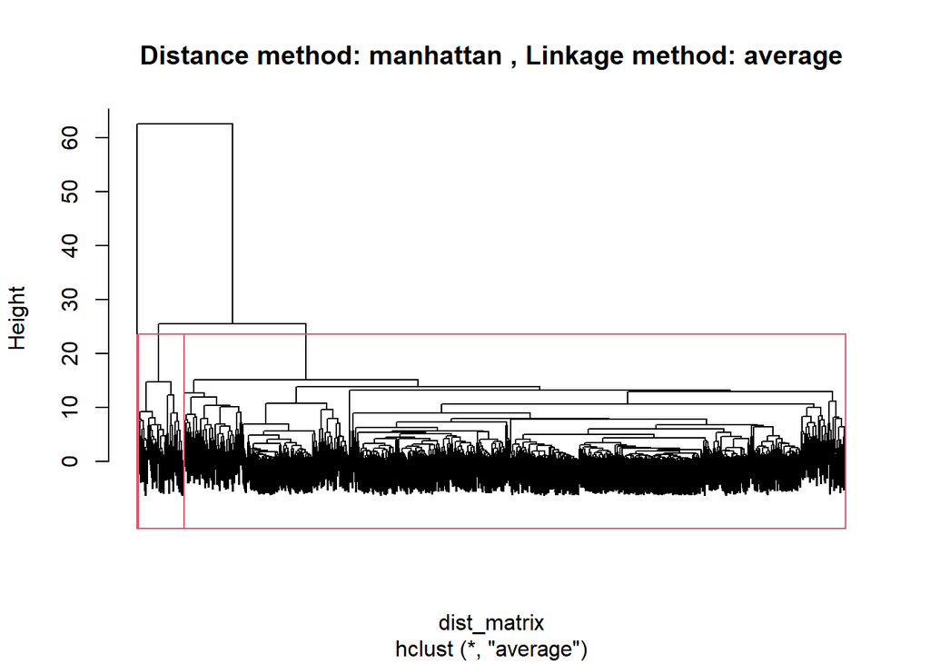

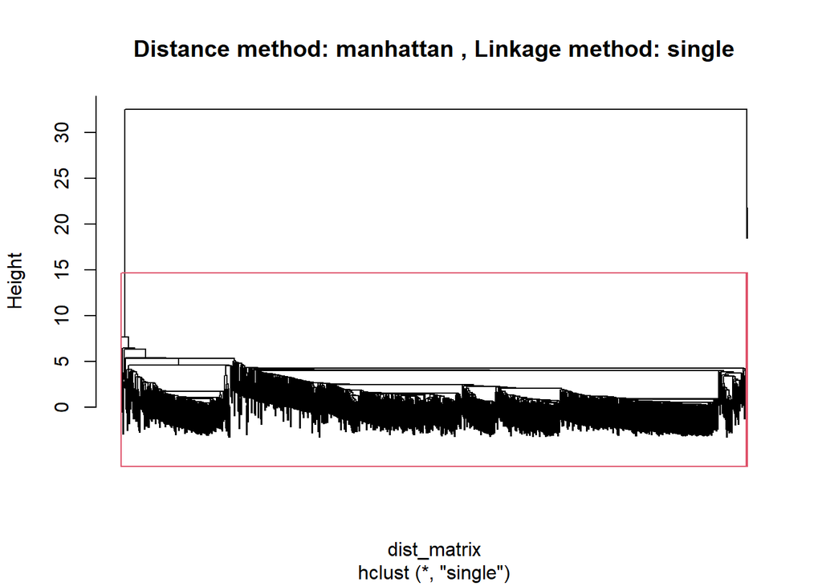

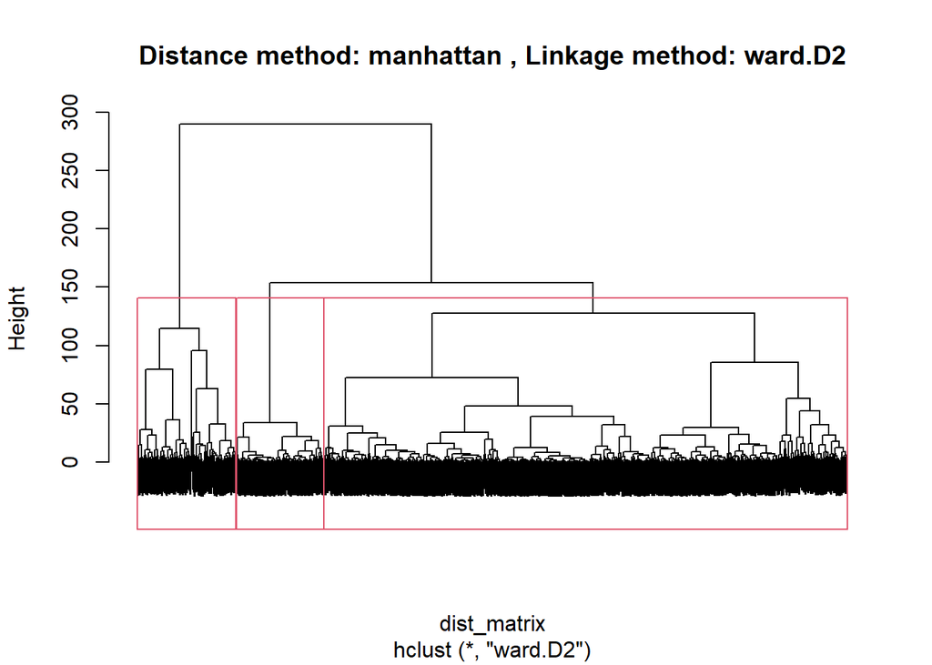

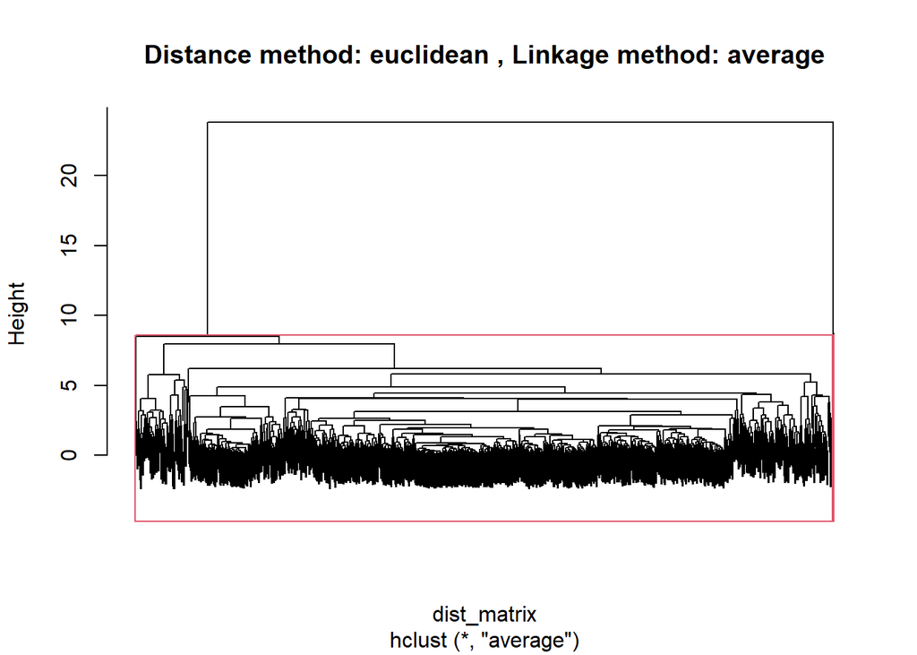

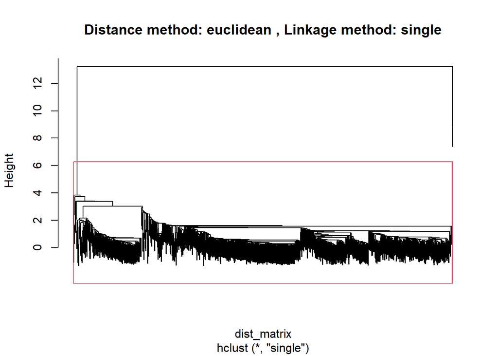

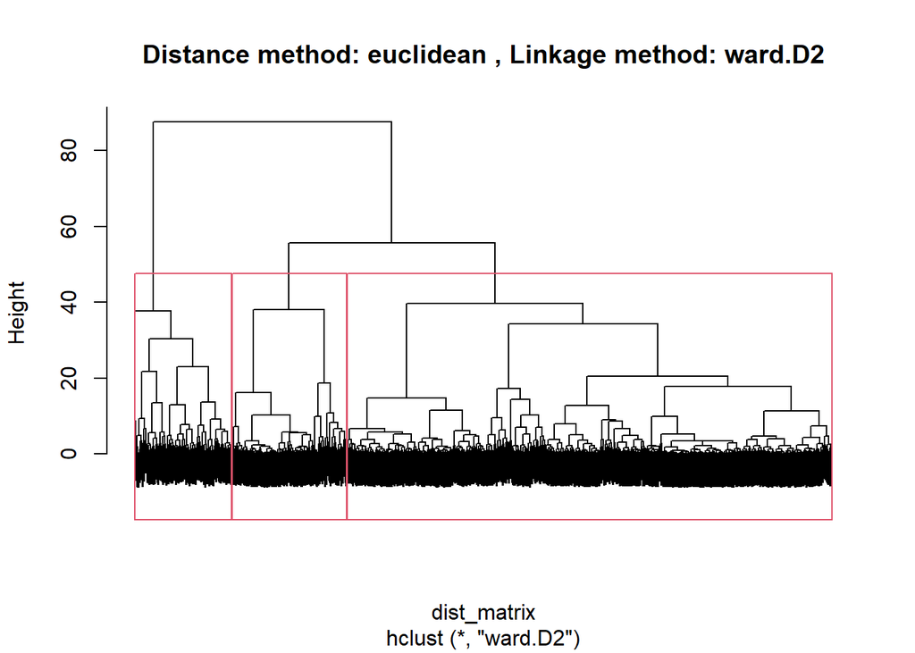

```r
# Define the distance methods and linkage methods for hierarchical clustering
distance_methods <- c("manhattan", "euclidean")
linkage_methods <- c("average", "single", "ward.D2")

# Initialize a list to store the results of each clustering configuration
all_cluster_results <- list()

# Loop through each combination of distance and linkage methods
for (dist_method in distance_methods) {
  for (linkage_method in linkage_methods) {
    # Compute the distance matrix for the given distance method
    dist_matrix <- dist(clustering_numeric_data, method = dist_method)
    # Perform hierarchical clustering using the computed distance matrix and the given linkage method
    cluster_result <- hclust(dist_matrix, method = linkage_method)
    # Store the clustering result in the results list with a unique key based on the distance and linkage methods
    all_cluster_results[[paste(dist_method, linkage_method, sep="_")]] <- cluster_result
    # Plot the dendrogram for the clustering result
    plot(cluster_result, labels = FALSE, main = paste("Distance method:", dist_method, ", Linkage method:", linkage_method))
    rect.hclust(cluster_result, k=3)
  }
}
```

```r
# Extract cluster memberships for the last clustering result with k=3
groups <- cutree(cluster_result, k=3)
```

The dendrogram is a visual representation of how the clusters are merged iteratively. The vertical lines on the dendrogram indicate the dissimilarity (or distance) at which two clusters are merged. A longer vertical line suggests a greater distance or dissimilarity.

Deciding on the Number of Clusters:

Elbow Method: An effective method to determine the ideal number of clusters is by looking for an “elbow” in the dendrogram. This is the point where the merging distance starts to increase significantly, indicating that further merges might not be meaningful. In many visually appealing plots, it’s often observed that cutting the dendrogram to produce three clusters is ideal, as the merging distance increases rapidly beyond this point. Selection of Distance and Linkage Methods:

Visual Clustering

Data Preparation

First, we use Principal Component Analysis (PCA) to reduce the high-dimensional data into a simpler form, preserving as much of the original variance as possible.

Then projects the data into a 2D space using the first two principal components. This projection facilitates visualization by translating the multi-dimensional data into a format that can be easily plotted on a two-dimensional plane.

The 2D projections are enriched by appending cluster assignments and country information to each data point. This makes the subsequent visualizations more informative, showing not only the cluster each point belongs to but also the country it’s associated with

We also visualize Cluster boundary. It provide a clear visual representation of each cluster’s spread in the 2D space, the code computes the convex hull for each cluster. A convex hull is the smallest convex polygon that encompasses all points of a cluster, effectively showing the boundary of the cluster.

```r
# Perform principal component analysis (PCA) on the numeric data
princ <- prcomp(clustering_numeric_data)

# Number of components to retain for projection (in this case 2D)
nComp <- 2

# Project the data into the first two principal components
project2D <- as.data.frame(predict(princ, newdata=clustering_numeric_data)[,1:nComp])

# Combine the 2D projections with cluster groups and country information
hclust_project2D <- cbind(project2D, cluster=as.factor(groups), country=clustering_data$country)

# Define a function to compute the convex hull for each cluster in the 2D projection
find_convex_hull <- function(proj2Ddf, groups) {
  do.call(rbind,
          lapply(unique(groups),
                 FUN = function(c) {
                   f <- subset(proj2Ddf, cluster==c)
                   f[chull(f),]
                 }
          )
  )
}

# Compute the convex hull for each cluster
hclust_hull <- find_convex_hull(hclust_project2D, groups)
```

Visualize CH index plot and WSS plot.

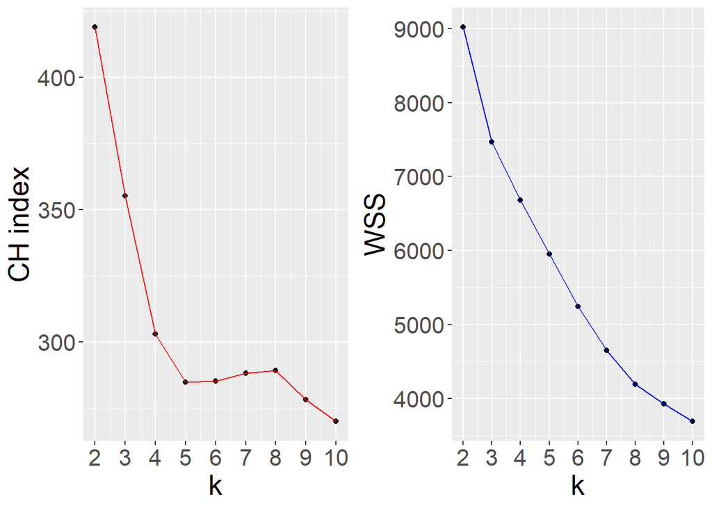

```r
# Compute the CH Index for the clustering numeric data using hierarchical clustering
crit.df <- CH_index(clustering_numeric_data, 10, method="hclust")

# Handle potential missing values
crit.df <- na.omit(crit.df)

# Plotting
# Plot the CH index against k values
CHIndexPlot <- ggplot(crit.df, aes(x=k, y=CH_index)) +
  geom_point() + geom_line(colour="red") +
  scale_x_continuous(breaks=1:10, labels=1:10) +
  labs(y="CH index") + theme(text=element_text(size=20))

# Plot the WSS against k values
WSSPlot <- ggplot(crit.df, aes(x=k, y=WSS)) +
  geom_point() + geom_line(colour="blue") +
  scale_x_continuous(breaks=1:10, labels=1:10) +
  labs(y="WSS") + theme(text=element_text(size=20))

# Display both plots side by side
grid.arrange(CHIndexPlot, WSSPlot, nrow=1)
```

This graph shows how the CH index (Calinski-Harabasz Index) and WSS (sum of squares within clusters) vary with the value of k (i.e., the number of clusters), respectively. Given the diversity of readers, we will analyze the graphs in order to increase readability

CH Index:

The CH index (Calinski-Harabasz Index) is a metric used to evaluate the effectiveness of clustering.

The CH index is the ratio of inter-cluster distance to intra-cluster distance. A high CH index indicates that points within clusters are very close to each other and relatively far from other clusters, which is what we want to see for good clustering.

We can see that the CH index reaches its maximum value at k=2, which means that k=2 provides the best ratio of inter-cluster distance to intra-cluster distance. That is, when there are only two clusters, intra-cluster similarity and inter-cluster dissimilarity are best.

WSS (intra-cluster sum of squares):

WSS measures the total distance from all points within a cluster to its cluster center. A smaller WSS means that points within a cluster are closer to its center, thus forming tighter clusters.

At increasing values of k, we expect the WSS to decrease because more clusters mean fewer points within each cluster, and thus less intra-cluster distance.

However, we are not seeking to minimize the WSS, but rather to find a suitable value of k at which increasing the number of clusters no longer significantly reduces the WSS. This “turning point” or “elbow” is often used to select the right value of k. In the graph we provided, the WSS is reduced by a factor of k.

The drop in WSS from k=2 to k=3 is the most significant, suggesting that k=2 to k=3 brings the greatest improvement in clustering. After that, the decrease in WSS slows down, which means that adding more clusters does not significantly improve the clustering. For WSS, instead of aiming for the highest value, we look for the “elbow”, where the WSS decline starts to slow down. k=3 neighborhood may be a suitable choice.

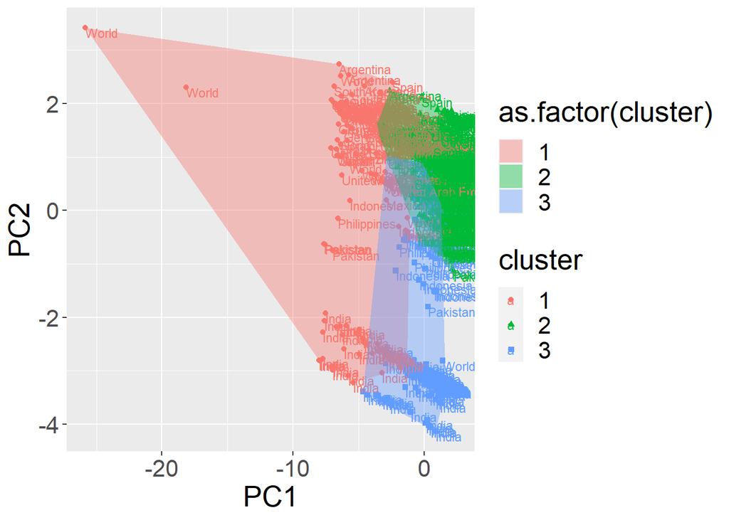

```r
# Use ggplot visualize Clustering
ggplot(hclust_project2D, aes(x=PC1, y=PC2)) +
  geom_point(aes(shape=cluster, color=cluster)) +
  geom_text(aes(label=country, color=cluster), hjust=0, vjust=1, size=3) +
  geom_polygon(data=hclust_hull, aes(group=cluster, fill=as.factor(cluster)), alpha=0.4, linetype=0) +
  theme(text=element_text(size=20))
```

In the chart, we have a K of 3, with 3 squares, and there are overlapping parts between each square, with fewer parts overlapping in all three squares. We believe this is due to the fact that the data was chosen from the top 1,000 tanker bloggers, out of the millions of tanker bloggers, these 1,000 represent the head of all tanker bloggers, which inevitably leads to duplication of area, followed by the fact that many countries are duplicated multiple times, and although the other data varies from blogger to blogger, each feature is not independent, and they are linked to the country’s geographic location, which leads to overlapping area as well

## 5.6 K-means Clustering

Next, the code performs clustering using the k-means algorithm, where the optimal value of k is set to 5. The kmeans method is used to find the centers of the clusters and assign data points to the nearest centers.

Finally, the code uses the fpc library to compute the CH index and ASW values, which help evaluate the quality of clustering for different values of k. A higher CH index indicates greater inter-cluster variation and less intra-cluster variation, while ASW measures the cohesiveness of the clusters, with values closer to 1 indicating better clustering.

```r
# Identify and display the two most stable clusters
cat("Thus, clusters", order(-stability_values)[1], "and", order(-stability_values)[2], "are highly stable")
```

```
## Thus, clusters 2 and 3 are highly stable
```

```r
# Perform clustering using the k-means algorithm with the optimal value for k set to 5
optimalKValue <- 5
kMeansResult <- kmeans(clustering_numeric_data, optimalKValue, nstart=100, iter.max=100)

# Get the cluster results from k-means
clusterGroups <- kMeansResult$cluster

# Calculate CH index and ASW values for k values ranging from 1 to 10 using the fpc library
kMeansCH <- kmeansruns(clustering_numeric_data, krange=1:10, criterion="ch")
kMeansASW <- kmeansruns(clustering_numeric_data, krange=1:10, criterion="asw")

# Combine k-means CH index and ASW values into a single data frame
kMeansMetrics <- data.frame(k=1:10, CH_index=kMeansCH$crit, ASW=kMeansASW$crit)
```

First, we use the ggplot2 library to plot the CH index and ASW values against the k-value (number of clusters).The CH index is used to assess the differences between different clusters, while the ASW values assess the internal cohesion of each cluster. Both metrics are used to help select the best k-value.

Then, for k values from 2 to 5, we used the k-means algorithm for clustering and projected these results onto a 2D graph. Also, for each value of k, a convex hull is computed to represent the boundary of each cluster.

Finally, we display the clustering results of these four k-values side-by-side in a 2x2 grid using the grid.range function.

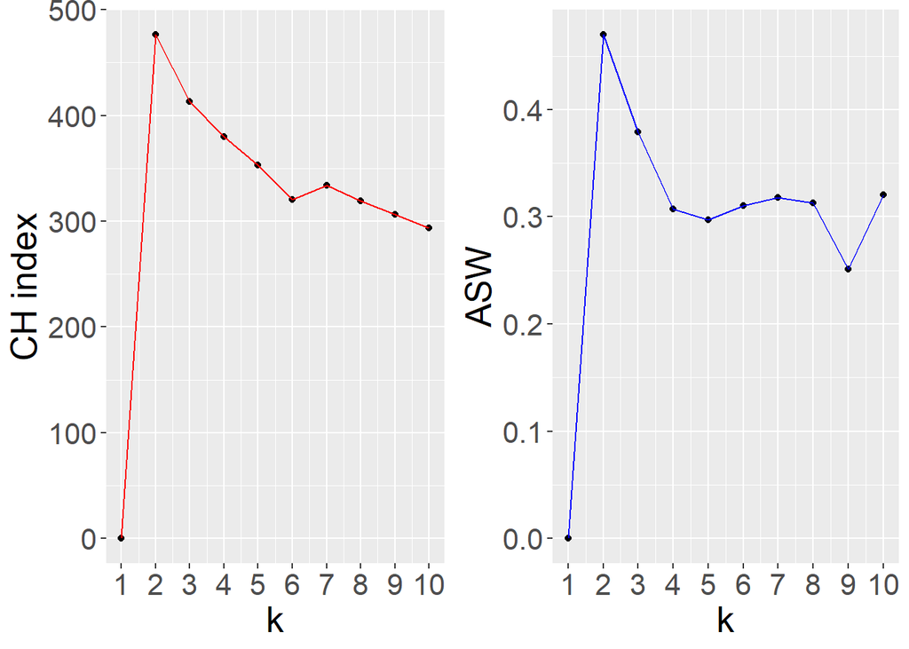

```r
# Plot the CH index against k values
CHIndexPlot <- ggplot(kMeansMetrics, aes(x=k, y=CH_index)) +
  geom_point() + geom_line(colour="red") +
  scale_x_continuous(breaks=1:10, labels=1:10) +
  labs(y="CH index") + theme(text=element_text(size=20))

# Plot the ASW against k values
ASWPlot <- ggplot(kMeansMetrics, aes(x=k, y=ASW)) +
  geom_point() + geom_line(colour="blue") +
  scale_x_continuous(breaks=1:10, labels=1:10) +
  labs(y="ASW") + theme(text=element_text(size=20))

# Display both plots side by side
grid.arrange(CHIndexPlot, ASWPlot, nrow=1)
```

CH Index Chart:

In this graph, the CH index reaches a peak when k=2, which indicates that with k=2 we get relatively better clustering because the data points within the clusters are relatively centralized and the distances to other clusters are larger.

As the value of k increases, the CH index gradually decreases, which may mean that the increased clusters do not make the data better clustered.

ASW (Average contour coefficient) Graph.

Average contour coefficient is a measure of the difference between the average distance of a data point to other data points in its cluster and the average distance of the data point to the nearest other cluster. Values closer to 1 indicate better clustering, while values closer to -1 indicate worse clustering.

From the graph, ASW reaches a high value at k=2 and then fluctuates. This means that clustering is relatively better at k=2.

Based on these two graphs, we can tentatively conclude that clustering is relatively better at k=2.

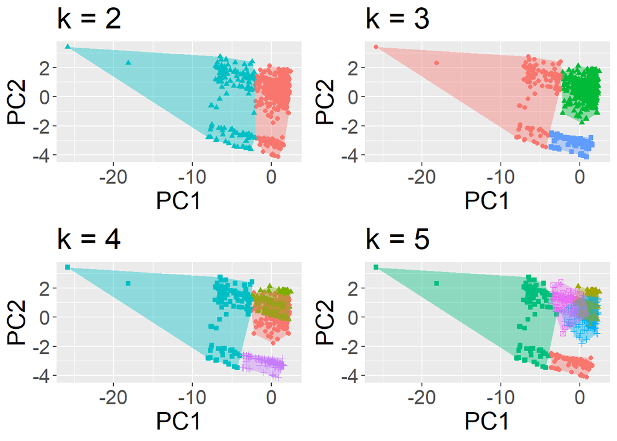

```r
# For k values ranging from 2 to 5, plot the results of the k-means clustering
plotList <- list()
kRange <- 2:5
for (currentK in kRange) {
  currentClusters <- kmeans(clustering_numeric_data, currentK, nstart=100, iter.max=100)$cluster
  kMeansProjection2D <- cbind(project2D, cluster=as.factor(currentClusters), country=clustering_data$country)
  kMeansHull <- find_convex_hull(kMeansProjection2D, currentClusters)

  currentPlot <- ggplot(kMeansProjection2D, aes(x=PC1, y=PC2)) +
    geom_point(aes(shape=cluster, color=cluster)) +
    geom_polygon(data=kMeansHull, aes(group=cluster, fill=cluster), alpha=0.4, linetype=0) +
    labs(title = sprintf("k = %d", currentK)) +
    theme(legend.position="none", text=element_text(size=20))

  plotList[[currentK - 1]] <- currentPlot
}

# Display k-means clustering results in a 2x2 grid
grid.arrange(plotList[[1]], plotList[[2]], plotList[[3]], plotList[[4]], nrow=2)
```

k = 2:

The data are divided into two distinct clusters, one of which is predominantly in the negative region of PC1, and the other is concentrated in the region close to 0 of PC1. there is a clear boundary between the two clusters.

k = 3:

The data is divided into three clusters. Among them, the red and blue clusters are similar to the division at k = 2.

The added green cluster is mainly concentrated in the positive region of PC2, and there is also a clear boundary between it and the blue cluster.

k = 4:

k = 5:

The data is divided into five clusters, but here the boundaries between clusters start to become less distinct compared to the k = 4 case.

From the above analysis, we see that:

The clustering seems to work best when k=2 and k=3 because each cluster has clear boundaries and there is not much overlap.

When k increases to 4 or 5, the boundaries between clusters start to blur, especially at k=5, although we can identify more subclusters.

Combining the previous CH index and ASW analyses, and considering the clarity of clustering and the boundaries between clusters, we believe that k=2 or k=3 can be used as the optimal number of clusters.

# Reference

[1] Elgiriyewithana, N. (2023). Global YouTube Statistics 2023. Kaggle. https://www.kaggle.com/datasets/nelgiriyewithana/global-youtube-statistics-2023

[2] Wickham, H. (2016). ggplot2: Elegant Graphics for Data Analysis. Springer-Verlag New York. https://ggplot2.tidyverse.org

[3] Wickham, H., François, R., Henry, L., & Müller, K. (2021). dplyr: A Grammar of Data Manipulation (R package version 1.0.7). https://dplyr.tidyverse.org

[4] Friendly, M. (2002). Corrgrams: Exploratory displays for correlation matrices. The American Statistician, 56(4), 316–324.

[5] McNamara, A., Zhu, H., Arino de la Rubia, E., Ellis, S., Lowndes, J., & Quinn, M. (2021). skimr: Compact and Flexible Summaries of Data (R package version 2.1.3). https://cran.r-project.org/web/packages/skimr/

[6] Healy, K. (2018). Data Visualization: A Practical Introduction. Princeton University Press.

[7] Joanes, D. N., & Gill, C. A. (1998). Comparing measures of sample skewness and kurtosis. The Statistician, 47(1), 183-189.

[8] Kuhn, M. (2019). The caret Package 4.1 Simple Splitting Based on the Outcome. http://topepo.github.io/caret/data-splitting.html

[9] Feng, C., Wang, H., Lu, N., Chen, T., He, H., Lu, Y., & Tu, X. M. (2014). Log-transformation and its implications for data analysis. Shanghai Arch Psychiatry, 26(2), 105-109.

[10] Hastie, T., Tibshirani, R., & Friedman, J. (2009). The Elements of Statistical Learning: Data Mining, Inference, and Prediction. Springer.

[11] OpenAI. (2023). ChatGPT (August 3 Version) [Large language model]. https://chat.openai.com